# Project 2 - Group 2

# Group 2

Joseph Elikishvili  
Andrew Goldberg  
Daniel Hong  
Christophe Hunt - Group Leader

# Overview

### Abstract

The purpose of this report is to address the new regulations and to better understand the manufacturing process within ABC Beverage. We will examine all factors involved in the production process and will attempt to identify the factors that will help us properly predict the PH levels as well us understand the influence of the various factors on the overall process.

### Data used

This report is using the historical data collected from approximately 2572 samples which should be sufficient for the analysis.

### Brief overview of the process

We will first cleanup the data, by filling in or imputing the missing data, use various transformation methods in order to normalize the data to address issues such as outlier data points and other normalization related issues.

Next we will run various models in order to identify the factors that are important to reaching out goal and once we have those we will use various models in order to estimate the PH levels and come up with a best suiting method that we feel will be best to predict the data we are looking for.

We will include documented R code within the report so that it is easy to follow our research. Should you have any questions regarding the process or the code, feel free to reach out to our department.

# Data Exploration

We will get started by loading our historical data into a data frame and loading the necessary libraries.

```r
library(missForest)
library(corrgram)
library(caret)
library(psych)
library(knitr)
dfBevMod <- read.csv("https://github.com/ChristopheHunt/CUNY-DATA624/raw/master/data/StudentData.csv", header = TRUE)
dfBevPred <- read.csv("https://raw.githubusercontent.com/ChristopheHunt/CUNY-DATA624/master/data/StudentEvaluation-%20TO%20PREDICT.csv", header =TRUE)
```

We will examine the training dataset we want to see how many predictor variables we are dealing with and if we are missing any data. We see several variables with missing data,

```r
dim(dfBevMod)
```

```
[1] 2571   33
```

It appears we have a total of 32 predictor variables and a target variable. Next we will check for any missing data.

```r
colSums(is.na(dfBevMod))
```

```
       Brand.Code       Carb.Volume       Fill.Ounces         PC.Volume     Carb.Pressure         Carb.Temp
                0                10                38                39                27                26
              PSC          PSC.Fill           PSC.CO2          Mnf.Flow    Carb.Pressure1     Fill.Pressure
               33                23                39                 2                32                22
    Hyd.Pressure1     Hyd.Pressure2     Hyd.Pressure3     Hyd.Pressure4      Filler.Level      Filler.Speed
               11                15                15                30                20                57
      Temperature        Usage.cont         Carb.Flow           Density               MFR           Balling
               14                 5                 2                 1               212                 1
  Pressure.Vacuum                PH     Oxygen.Filler     Bowl.Setpoint Pressure.Setpoint     Air.Pressurer
                0                 4                12                 2                12                 0
         Alch.Rel          Carb.Rel       Balling.Lvl
                9                10                 1
```

We see many variables with NA’s – notably “MFR” has 212. Still, roughly 8% NA is workable, so we’ll choose to use imputation process to fill in the missing data.

Also, it appears that we have one categorical variable: Brand.Code

### Barchart

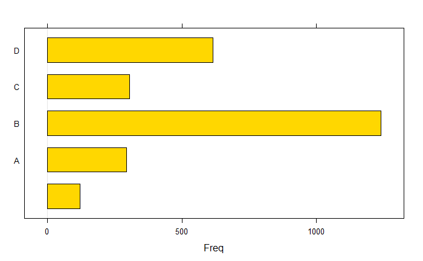

```r
#Visualizing the single categorical variable
barchart(dfBevMod[,1], col="Gold")
```

It appears that brand “B” occurs most frequently, followed by “D”

### Continuous and Discrete variables

Next we will review all the variables we are working with in order to better understand the data they are presenting us. We can see the mean, variation and other metrics within the following table for a quick detailed reference.

```r
library(psych)
library(knitr)
table.desc <- describe(dfBevMod[,-1])
table.prep <- as.matrix(table.desc)
table.round <- round((table.prep), 2)
kable(table.round)
```

|  | vars | n | mean | sd | median | trimmed | mad | min | max | range | skew | kurtosis | se |
| --- | --- | --- | --- | --- | --- | --- | --- | --- | --- | --- | --- | --- | --- |
| Carb.Volume | 1 | 2561 | 5.37 | 0.11 | 5.35 | 5.37 | 0.11 | 5.04 | 5.70 | 0.66 | 0.39 | -0.47 | 0.00 |
| Fill.Ounces | 2 | 2533 | 23.97 | 0.09 | 23.97 | 23.98 | 0.08 | 23.63 | 24.32 | 0.69 | -0.02 | 0.86 | 0.00 |
| PC.Volume | 3 | 2532 | 0.28 | 0.06 | 0.27 | 0.27 | 0.05 | 0.08 | 0.48 | 0.40 | 0.34 | 0.67 | 0.00 |
| Carb.Pressure | 4 | 2544 | 68.19 | 3.54 | 68.20 | 68.12 | 3.56 | 57.00 | 79.40 | 22.40 | 0.18 | -0.01 | 0.07 |
| Carb.Temp | 5 | 2545 | 141.09 | 4.04 | 140.80 | 140.99 | 3.85 | 128.60 | 154.00 | 25.40 | 0.25 | 0.24 | 0.08 |
| PSC | 6 | 2538 | 0.08 | 0.05 | 0.08 | 0.08 | 0.05 | 0.00 | 0.27 | 0.27 | 0.85 | 0.65 | 0.00 |
| PSC.Fill | 7 | 2548 | 0.20 | 0.12 | 0.18 | 0.18 | 0.12 | 0.00 | 0.62 | 0.62 | 0.93 | 0.77 | 0.00 |
| PSC.CO2 | 8 | 2532 | 0.06 | 0.04 | 0.04 | 0.05 | 0.03 | 0.00 | 0.24 | 0.24 | 1.73 | 3.73 | 0.00 |
| Mnf.Flow | 9 | 2569 | 24.57 | 119.48 | 65.20 | 21.07 | 169.02 | -100.20 | 229.40 | 329.60 | 0.00 | -1.87 | 2.36 |
| Carb.Pressure1 | 10 | 2539 | 122.59 | 4.74 | 123.20 | 122.54 | 4.45 | 105.60 | 140.20 | 34.60 | 0.05 | 0.14 | 0.09 |
| Fill.Pressure | 11 | 2549 | 47.92 | 3.18 | 46.40 | 47.71 | 2.37 | 34.60 | 60.40 | 25.80 | 0.55 | 1.41 | 0.06 |
| Hyd.Pressure1 | 12 | 2560 | 12.44 | 12.43 | 11.40 | 10.84 | 16.90 | -0.80 | 58.00 | 58.80 | 0.78 | -0.14 | 0.25 |
| Hyd.Pressure2 | 13 | 2556 | 20.96 | 16.39 | 28.60 | 21.05 | 13.34 | 0.00 | 59.40 | 59.40 | -0.30 | -1.56 | 0.32 |
| Hyd.Pressure3 | 14 | 2556 | 20.46 | 15.98 | 27.60 | 20.51 | 13.94 | -1.20 | 50.00 | 51.20 | -0.32 | -1.57 | 0.32 |
| Hyd.Pressure4 | 15 | 2541 | 96.29 | 13.12 | 96.00 | 95.45 | 11.86 | 52.00 | 142.00 | 90.00 | 0.55 | 0.63 | 0.26 |
| Filler.Level | 16 | 2551 | 109.25 | 15.70 | 118.40 | 111.04 | 9.19 | 55.80 | 161.20 | 105.40 | -0.85 | 0.05 | 0.31 |
| Filler.Speed | 17 | 2514 | 3687.20 | 770.82 | 3982.00 | 3919.99 | 47.44 | 998.00 | 4030.00 | 3032.00 | -2.87 | 6.71 | 15.37 |
| Temperature | 18 | 2557 | 65.97 | 1.38 | 65.60 | 65.80 | 0.89 | 63.60 | 76.20 | 12.60 | 2.39 | 10.16 | 0.03 |
| Usage.cont | 19 | 2566 | 20.99 | 2.98 | 21.79 | 21.25 | 3.19 | 12.08 | 25.90 | 13.82 | -0.54 | -1.02 | 0.06 |
| Carb.Flow | 20 | 2569 | 2468.35 | 1073.70 | 3028.00 | 2601.14 | 326.17 | 26.00 | 5104.00 | 5078.00 | -0.99 | -0.58 | 21.18 |
| Density | 21 | 2570 | 1.17 | 0.38 | 0.98 | 1.15 | 0.15 | 0.24 | 1.92 | 1.68 | 0.53 | -1.20 | 0.01 |
| MFR | 22 | 2359 | 704.05 | 73.90 | 724.00 | 718.16 | 15.42 | 31.40 | 868.60 | 837.20 | -5.09 | 30.46 | 1.52 |
| Balling | 23 | 2570 | 2.20 | 0.93 | 1.65 | 2.13 | 0.37 | -0.17 | 4.01 | 4.18 | 0.59 | -1.39 | 0.02 |
| Pressure.Vacuum | 24 | 2571 | -5.22 | 0.57 | -5.40 | -5.25 | 0.59 | -6.60 | -3.60 | 3.00 | 0.53 | -0.03 | 0.01 |
| PH | 25 | 2567 | 8.55 | 0.17 | 8.54 | 8.55 | 0.18 | 7.88 | 9.36 | 1.48 | -0.29 | 0.06 | 0.00 |
| Oxygen.Filler | 26 | 2559 | 0.05 | 0.05 | 0.03 | 0.04 | 0.02 | 0.00 | 0.40 | 0.40 | 2.66 | 11.09 | 0.00 |
| Bowl.Setpoint | 27 | 2569 | 109.33 | 15.30 | 120.00 | 111.35 | 0.00 | 70.00 | 140.00 | 70.00 | -0.97 | -0.06 | 0.30 |
| Pressure.Setpoint | 28 | 2559 | 47.62 | 2.04 | 46.00 | 47.60 | 0.00 | 44.00 | 52.00 | 8.00 | 0.20 | -1.60 | 0.04 |
| Air.Pressurer | 29 | 2571 | 142.83 | 1.21 | 142.60 | 142.58 | 0.59 | 140.80 | 148.20 | 7.40 | 2.25 | 4.73 | 0.02 |
| Alch.Rel | 30 | 2562 | 6.90 | 0.51 | 6.56 | 6.84 | 0.06 | 5.28 | 8.62 | 3.34 | 0.88 | -0.85 | 0.01 |
| Carb.Rel | 31 | 2561 | 5.44 | 0.13 | 5.40 | 5.43 | 0.12 | 4.96 | 6.06 | 1.10 | 0.50 | -0.29 | 0.00 |
| Balling.Lvl | 32 | 2570 | 2.05 | 0.87 | 1.48 | 1.98 | 0.21 | 0.00 | 3.66 | 3.66 | 0.59 | -1.49 | 0.02 |

### Nominal Variable Histogram

Next we will visually view each one of the factors, its easier to visually navigate through a large number of variables. We are interested to see how data is distributed for each one of the variables. Please refer to above table for more specific information.

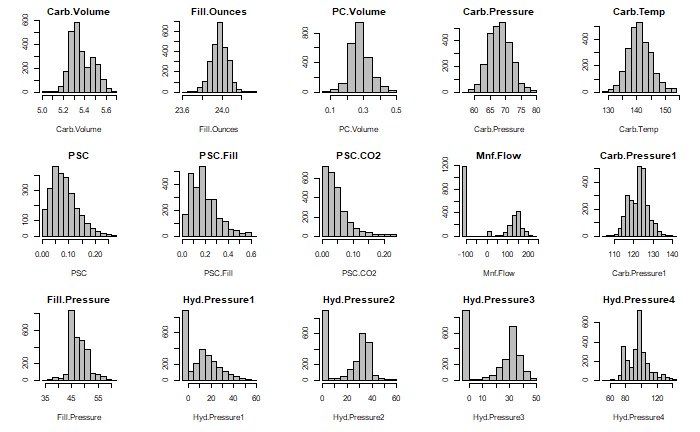

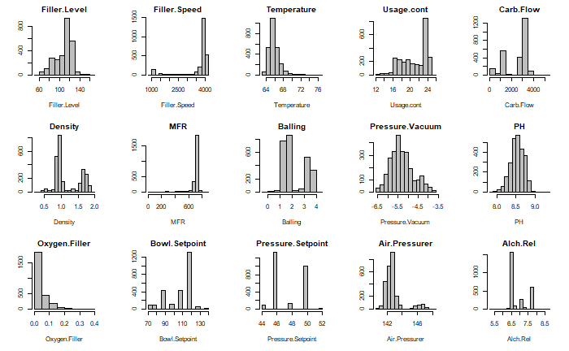

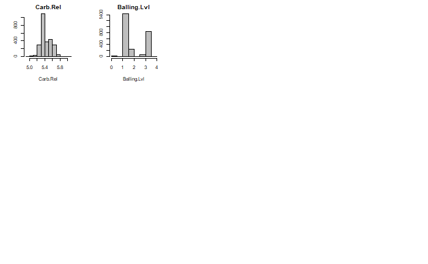

```r
dfBevModH <- dfBevMod[2:ncol(dfBevMod)] #removing factor var
par(mfrow = c(3,5), cex = .5)
for(i in colnames(dfBevModH)){
hist(dfBevModH[,i], xlab = names(dfBevMod[i]),
  main = names(dfBevModH[i]), col="grey", ylab="")
}
```

Next we want to explore differences by Brand

```r
BrandA <- dfBevMod[dfBevMod$Brand.Code == "A",]
BAM <- colMeans(BrandA[,2:ncol(BrandA)], na.rm = TRUE)
BrandB <- dfBevMod[dfBevMod$Brand.Code == "B",]
BBM <- colMeans(BrandB[,2:ncol(BrandB)], na.rm = TRUE)
BrandC <- dfBevMod[dfBevMod$Brand.Code == "C",]
BCM <- colMeans(BrandC[,2:ncol(BrandC)], na.rm = TRUE)
BrandD <- dfBevMod[dfBevMod$Brand.Code == "D",]
BDM <- colMeans(BrandD[,2:ncol(BrandD)], na.rm = TRUE)
BrandE <- dfBevMod[dfBevMod$Brand.Code == "",]
BEM <- colMeans(BrandE[,2:ncol(BrandE)], na.rm = TRUE)
combBrand <- cbind(BAM, BBM, BCM, BDM, BEM)
round(combBrand, 4)
```

```
                        BAM       BBM       BCM       BDM       BEM
Carb.Volume          5.4257    5.3125    5.3002    5.5104    5.2909
Fill.Ounces         23.9821   23.9775   23.9849   23.9566   23.9971
PC.Volume            0.2688    0.2824    0.2902    0.2617    0.2888
Carb.Pressure       69.2804   67.1980   66.9248   70.6982   66.2605
Carb.Temp          141.2288  141.1108  141.0536  141.1301  140.5179
PSC                  0.0776    0.0864    0.0898    0.0806    0.0904
PSC.Fill             0.1984    0.1937    0.2103    0.1910    0.1893
PSC.CO2              0.0555    0.0571    0.0621    0.0528    0.0559
Mnf.Flow            39.7147   20.4618   23.2809   25.7467   27.1533
Carb.Pressure1     122.8186  122.4750  122.1940  122.7236  123.4605
Fill.Pressure       48.2212   48.1701   48.2287   46.9612   48.7829
Hyd.Pressure1       12.9024   12.5247   12.3283   12.3967   10.8900
Hyd.Pressure2       21.1582   21.1051   19.1625   21.9733   18.4367
Hyd.Pressure3       20.9747   20.1925   19.0467   21.5901   19.7867
Hyd.Pressure4      101.2837  100.0586  102.5400   83.4528   95.9828
Filler.Level       108.6267  107.9616  111.6020  110.4226  112.1508
Filler.Speed      3582.0772 3730.6194 3673.6622 3688.9767 3517.8291
Temperature         66.0632   65.8908   66.7166   65.4621   67.2269
Usage.cont          21.1403   20.9662   21.0366   21.0065   20.7293
Carb.Flow         2387.3540 2532.7006 2311.5395 2437.1805 2557.4333
Density              1.5711    0.9084    0.9222    1.6825    0.9687
MFR                704.9837  705.6386  704.0283  703.9763  685.1028
Balling              3.1990    1.5111    1.6317    3.4856    1.6708
Pressure.Vacuum     -5.2389   -5.1543   -5.3105   -5.2602   -5.3333
PH                   8.4974    8.5668    8.4137    8.6025    8.4888
Oxygen.Filler        0.0415    0.0478    0.0516    0.0450    0.0473
Bowl.Setpoint      109.1134  107.7643  111.6184  110.8878  112.1667
Pressure.Setpoint   47.7622   47.9427   48.0337   46.6460   47.7983
Air.Pressurer      142.7358  142.9595  142.7664  142.6930  142.6717
Alch.Rel             7.1349    6.5505    6.5649    7.6935    6.6415
Carb.Rel             5.5177    5.3622    5.3524    5.6073    5.3442
Balling.Lvl          3.0771    1.4061    1.5206    3.2321    1.4687
```

Notable differences exist among brands by Hyd.Pressure4, Density, Balling, and Balling.Lvl

### Density Plot

Next we will use density plots to better understand the data and look for any abnormalities.

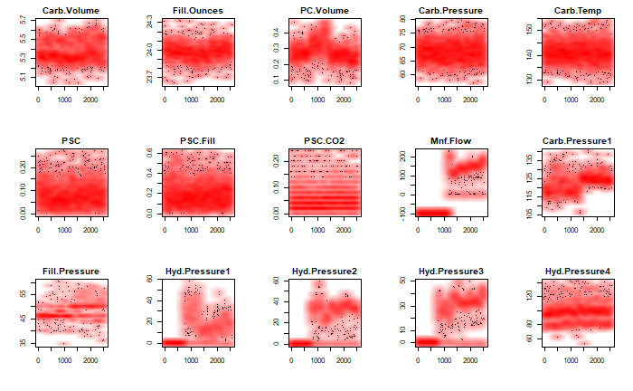

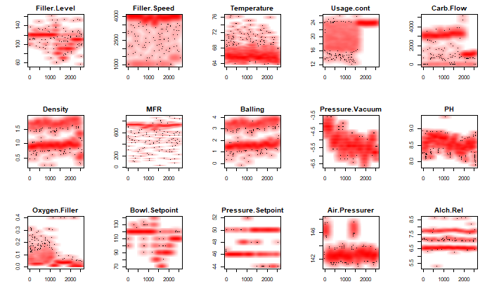

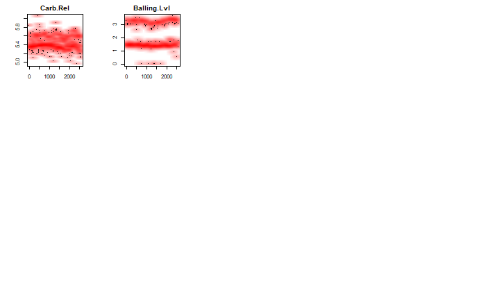

```r
par(mfrow = c(3,5), cex = .5)
for (i in colnames(dfBevModH)) {
 smoothScatter(dfBevModH[,i], main = names(dfBevModH[i]), ylab = "",
   xlab = "", colramp = colorRampPalette(c("white", "red")))
 }
```

The odd data in Mnf.Flow appears to be related to similarly zero-out data in Hyd.Pressure1, Hyd.Press2, and Hyd.Pressure3. Several other variables have dichotomous patterns in data behavior, including “Carb.Pressure1”, “Filler.Level”, “Usage.cont”, “Carb.Flow”, and “Oxygen.Filler”. This leaves two options; we can alter these gaps by possibly inputing new values in, or we can use algorithms that can easily handle quick pattern shifts, such as forests and MARS.

### BoxPlots

Next we want to take a look at any outliers within our variables. Boxplots provide a quick and effective way of view the data and look for any skew or outliers

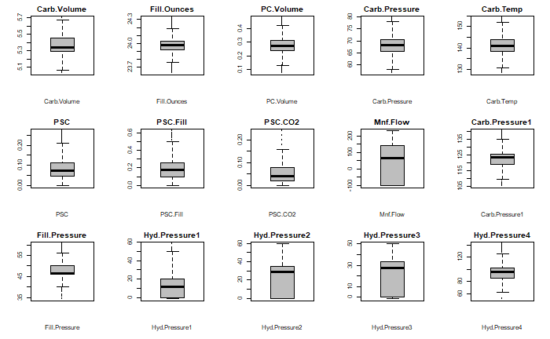

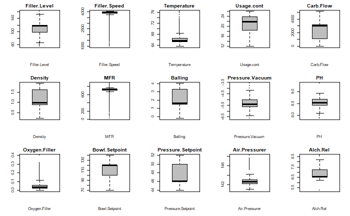

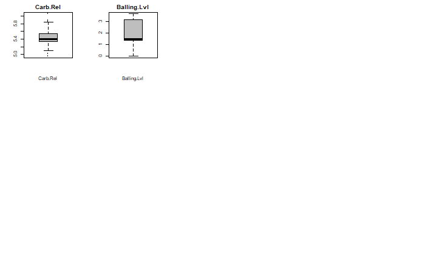

```r
par(mfrow = c(3,5), cex = .5)
for(i in colnames(dfBevModH)){
boxplot(dfBevModH[,i], xlab = names(dfBevModH[i]),
  main = names(dfBevModH[i]), col="grey", ylab="")
}
```

Again, several variables with large skews and outliers are present we will need to use transformation techniques later on to handle this issue.

### Principle Component Analysis

Since we are dealing with 32 predictor variables and not all of them can be relevant to our study, we will need a way to filter through the variables to reduce the number of variables we are working with. This can be done with PCA

```
$`Importance of Components`
                            PC1      PC2      PC3     PC4      PC5
Standard deviation     2.540088 2.449148 1.477634 1.47603 1.310421
Proportion of Variance 0.201630 0.187450 0.068230 0.06808 0.053660
Cumulative Proportion  0.201630 0.389070 0.457310 0.52539 0.579050

$`Rotation (Variable Loadings)`
                           PC1          PC2          PC3           PC4           PC5
Carb.Volume       -0.320871550  0.126525924 -0.063988169  0.0689976465 -0.1289819052
Fill.Ounces        0.033313610 -0.010524814  0.073850141  0.2358285280 -0.1229858345
PC.Volume          0.072479708 -0.108552900 -0.069562774 -0.3956296184  0.1598460185
Carb.Pressure     -0.208006297  0.060068377 -0.068128144  0.1465200114  0.5485412373
Carb.Temp         -0.033305138 -0.006187462 -0.040764654  0.1184540029  0.6879491706
PSC                0.034729843 -0.007932387  0.007672846  0.0166335686 -0.0797130932
PSC.Fill           0.005088232 -0.025583769 -0.008017467  0.0803836356 -0.1062661776
PSC.CO2            0.029539988  0.013537129 -0.010869845  0.1017169746 -0.0212550379
Mnf.Flow           0.080644367  0.358177152  0.044915507  0.0252965168 -0.0159976226
Carb.Pressure1     0.037910196  0.212302734  0.028684308  0.1765112631 -0.0290714575
Fill.Pressure      0.162738779  0.217724987 -0.208305845  0.0873750286  0.0003314597
Hyd.Pressure1      0.040714287  0.156202166  0.028117601 -0.4998183585  0.0951143049
Hyd.Pressure2      0.057453860  0.313403614  0.076107892 -0.3208825682  0.0947102915
Hyd.Pressure3      0.071682634  0.348252038  0.032135037 -0.2278539437  0.0851266883
Hyd.Pressure4      0.268513018 -0.023674824 -0.168038357 -0.0027778884 -0.0064600449
Filler.Level      -0.098309141 -0.276213319  0.109275148 -0.2476992005 -0.0659270082
Filler.Speed      -0.036355308  0.001197480  0.619301867  0.0628275426  0.1239047672
Temperature        0.105282829 -0.066203240 -0.105105120  0.0321416038  0.1020654842
Usage.cont         0.053341657  0.248028048  0.106147980  0.1153232541 -0.1185660052
Carb.Flow         -0.019747290 -0.192400631 -0.190052445  0.0123151046  0.1730300450
Density           -0.355713158  0.107013359 -0.067887877 -0.0009745302 -0.0203213313
MFR               -0.040893045 -0.001083672  0.620594464  0.0666977237  0.1118598210
Balling           -0.354342525  0.141148693 -0.040775757 -0.0141207975 -0.0496622835
Pressure.Vacuum   -0.046505652 -0.268137181  0.018936117  0.2043414157 -0.0377417295
PH                -0.115017697 -0.166446153 -0.043839565 -0.1546589220  0.0428191812
Oxygen.Filler     -0.017291886 -0.210617922 -0.096839733 -0.0417513911  0.0913810644
Bowl.Setpoint     -0.103923455 -0.273585690  0.086519475 -0.2471199864 -0.0734787536
Pressure.Setpoint  0.181047509  0.208820308 -0.105820469  0.0562644751  0.0479371223
Air.Pressurer      0.031569404 -0.035033996 -0.071242723  0.2609739989  0.0998622820
Alch.Rel          -0.364650212  0.099430202 -0.076928665 -0.0194895814 -0.0372397655
Carb.Rel          -0.352557712  0.079691885 -0.073882285 -0.0418290381 -0.0243017040
Balling.Lvl       -0.361905544  0.108856318 -0.069790925  0.0073156499 -0.0570128001
```

[output cut: 20 more lines]

```
Temperature       -0.032400811 -0.131025575 -0.131935567  0.013501453  0.103770602
Usage.cont         0.515662927  0.567466858  0.306198713 -0.105542769 -0.454543589
Carb.Flow         -0.728865476 -0.966223188 -0.604417233  0.368469211  0.950568080
Density           -0.117230400 -0.008474646  0.016244812  0.022657754  0.034322442
MFR               -0.455045229  0.066334864  0.812095962  0.771973495  0.224469906
Balling           -0.017953566  0.121197295  0.097470770 -0.026074148 -0.084814051
Pressure.Vacuum   -0.457986670 -0.407097197 -0.119183474  0.240746451  0.277242437
PH                -0.345239874 -0.323918002 -0.164411012 -0.017197343  0.211975600
Oxygen.Filler     -0.424027239 -0.467026196 -0.247762941  0.093078019  0.354347799
Bowl.Setpoint     -0.373730212 -0.214155886  0.007211244 -0.163635722  0.012366381
Pressure.Setpoint  0.411830072  0.282182390  0.035998404 -0.095125936 -0.169959804
Air.Pressurer     -0.075890499 -0.120293496 -0.078403739  0.157033933  0.125926876
Alch.Rel          -0.102425243  0.006988524  0.003604029 -0.018809036  0.005207278
Carb.Rel          -0.108413466  0.008531971  0.019415972 -0.047949293 -0.012596007
Balling.Lvl       -0.060110506  0.060109493  0.043885246 -0.025858266 -0.050934875
```

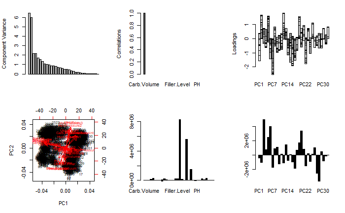

```r
PCA <- function(X) {
  Xpca <- prcomp(na.omit(X), center = T, scale. = T)
  M <- as.matrix(na.omit(X)); R <- as.matrix(Xpca$rotation); score <- M %*% R
  print(list("Importance of Components" = summary(Xpca)$importance[ ,1:5],
             "Rotation (Variable Loadings)" = Xpca$rotation[ ,1:5],
             "Correlation between X and PC" = cor(na.omit(X), score)[ ,1:5]))
  par(mfrow=c(2,3))
  barplot(Xpca$sdev^2, ylab = "Component Variance")
  barplot(cor(cbind(X)), ylab = "Correlations")
  barplot(Xpca$rotation, ylab = "Loadings")
  biplot(Xpca); barplot(M); barplot(score)
}
PCA(dfBevModH)
```

# Data Transformation

Since Brand Code is a categorical variable, we will have to transform it to a binary so that models can use the data.

```r
#df_imputed$Brand.Code = NULL
dfBevMod$Brand.Code[dfBevMod$Brand.Code == ""] <- NA
dfBevMod$Brand.Code <- droplevels(dfBevMod$Brand.Code)
dfBevPred$Brand.Code[dfBevPred$Brand.Code == ""] <- NA
dfBevPred$Brand.Code <- droplevels(dfBevPred$Brand.Code)
#Recode categorical factor
dfBevMod$A <- ifelse(dfBevMod$Brand.Code == "A", 1, 0)
dfBevMod$B <- ifelse(dfBevMod$Brand.Code == "B", 1, 0)
dfBevMod$C <- ifelse(dfBevMod$Brand.Code == "C", 1, 0)
dfBevMod$D <- ifelse(dfBevMod$Brand.Code == "D", 1, 0)
dfBevMod$Brand.Code <- NULL
dfBevPred$A <- ifelse(dfBevPred$Brand.Code == "A", 1, 0)
dfBevPred$B <- ifelse(dfBevPred$Brand.Code == "B", 1, 0)
dfBevPred$C <- ifelse(dfBevPred$Brand.Code == "C", 1, 0)
dfBevPred$D <- ifelse(dfBevPred$Brand.Code == "D", 1, 0)
dfBevPred$Brand.Code <- NULL
```

### Imputation

Next we will use the missForest library to impute the missing variable of the predictor variables. The library will use the best method in filling in the missing data.

Please note: We need to perform this step in order to have a complete dataset. Most models will not run on a data set with missing data. This is a common step in data science and filling in the data does not compromise the final results

```r
library(tidyverse)
#dfImpMod = missForest(dfBevMod)
#dfImpMod$OOBerror #error rate looks good?
#dfModImp <- dfImpMod$ximp
#dfImpPred <- missForest(dfBevPred)
#dfPredImp <- dfImpPred$ximp
#dfPredImp$PH <- NA #redadding PH
#write.csv(dfModImp, "TrainImputeData.csv")
#write.csv(dfPredImp, "PredictImputeData.csv")
#Stored current imputation results on github to quicken knitr iterations
dfModImp <- read.csv("https://raw.githubusercontent.com/ChristopheHunt/CUNY-DATA624/master/data/TrainImputeData.csv") %>% dplyr::select(-X)
dfPredImp <- read.csv("https://raw.githubusercontent.com/ChristopheHunt/CUNY-DATA624/master/data/PredictImputeData.csv") %>% dplyr::select(-X)
```

### Preprocessing

Next we will preprocess the data using various methods, this step will handle the issues of outliers and will get the data in the final stage where it can be used with the predictive models. Due to the different types of model inputs (some preprocess, other’s dont), we will be creating a range of preprocessed variables

```r
dfModImpX <- dfModImp[,!(names(dfModImp) == "PH")]
dfModImpY <- dfModImp[, names(dfModImp) == "PH"]
dfPredImpX <- dfPredImp[,!(names(dfPredImp) == "PH")]
dfPredImpY <- dfPredImp[, names(dfPredImp) == "PH"]
#Spatial Sign outlier processing
dfModImpSsX <- spatialSign(dfModImpX)
dfPredImpSsX <- spatialSign(dfPredImpX)
#BoxCox Only
transModB <- preProcess(dfModImpSsX, method = "BoxCox") #transformed all 22 variables
dfModBX <- predict(transModB, dfModImpSsX)
transPredB <- preProcess(dfPredImpSsX, method = "BoxCox") #transformed 23 variables (should we use the Modeling model from above, instead of predicting model?)
dfPredBX <- predict(transPredB, dfPredImpSsX)
#BoxCox, Centering, and Scaling
transModBCS <- preProcess(dfModImpSsX, method = c("BoxCox", "center", "scale")) #22 BC, 35 centered, 35 scaled
dfModBCSX <- predict(transModBCS, dfModImpSsX)
transPredBCS <- preProcess(dfPredImpSsX, method = c("BoxCox", "center", "scale")) #23 BC, 35 centered, 35 scaled
dfPredBCSX <- predict(transPredBCS, dfPredImpSsX)
#BoxCox, Centering, Scaling, and PCA
transModBCSP <- preProcess(dfModImpSsX, method = c("BoxCox", "center", "scale", "pca")) #22 BC, 35 centered, 35 scaled
dfModBCSPX <- predict(transModBCSP, dfModImpSsX)
transPredBCSP <- preProcess(dfPredImpSsX, method = c("BoxCox", "center", "scale", "pca")) #23 BC, 35 centered, 35 scaled
dfPredBCSPX <- predict(transPredBCSP, dfPredImpSsX)
```

Next we will attempt to reduce the number of predictor variables. We will review the correlation between the variables and find the highly correlated ones that can be reduced.

[figure not shown]

```r
#corrgram(dfModBCSX, order=TRUE,
#         upper.panel=panel.cor, main="Correlation Matrix")
library(corrplot)
#install.packages("corrplot")
correlations <- cor(dfModBCSX)
corrplot(correlations, order = "hclust", tl.cex = 0.55)
```

We can see several very highly correlated variables. We will reduce our dataset and remove pairs that have correlation above 0.75.

```r
hc = findCorrelation(correlations, cutoff=0.75)
length(hc) #18 vars
```

```
[1] 18
```

```r
#Reducing
dfModBCSRX = dfModBCSX[,-c(hc)] #Box-Cox, Center, Scale
dfPredBCSRX = dfPredBCSX[,-c(hc)]
dfModBRX = dfModBX[,-c(hc)] #Box-Cox
dfPredBRX = dfPredBX[,-c(hc)]
dfModSRX = dfModImpSsX[,-c(hc)] #Only Spatial Sign
dfPredSRX = dfPredImpSsX[,-c(hc)]
```

Finalizing data

```r
set.seed(2017)
n75 <- floor(0.75 * nrow(dfBevMod)) #75$ of sample size
n <- sample(seq_len(nrow(dfBevMod)), size = n75)
#Box-Cox, Center, Scale
dfTrainBCSX <- dfModBCSRX[n,]
dfTestBCSX <- dfModBCSRX[-n,]
#Box-Cox
dfTrainBX <- dfModBRX[n,]
dfTestBX <- dfModBRX[-n,]
#Only Spatial Sign
dfTrainX <- dfModSRX[n,]
dfTestX <- dfModSRX[-n,]
#Response variable
dfTrainY <- dfModImpY[n]
dfTestY <- dfModImpY[-n]
```

At this point data is ready and we can proceed to the modeling step.

# Model Development

## Regression Trees and Rule-based Models

### Partial Least Squares Regression (PLSR)

Partial Least Squares Regression (PLSR) is a multivatiate method related to Principal Components Regression (PCR) that differs because it finds a linear regression that projects predicted and observed values to a new space. These methods are helpful in situations where there are many potentially correlated predictor variables and relatively small samples. In theory, PLSR should be a better method than PCA, because if too few components are selected there could potentially be bad predictions. However, in practice, there doesn’t appear to be much difference in most situations as there are very similar prediction accuracies.

```r
set.seed(1234)
plsFit = plsr(PH ~ ., data=dfModImp, validation="CV")
pls.pred = predict(plsFit, dfPredImp[1:5, ], ncomp=1:2)
pls.pred
```

```
, , 1 comps

        PH
1 8.559928
2 8.558865
3 8.562908
4 8.481152
5 8.567435

, , 2 comps

        PH
1 8.556693
2 8.554464
3 8.559853
4 8.523944
5 8.565510
```

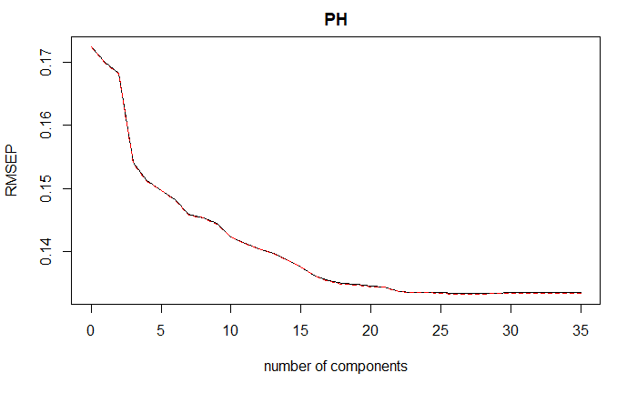

```r
validationplot(plsFit, val.type="RMSEP")
```

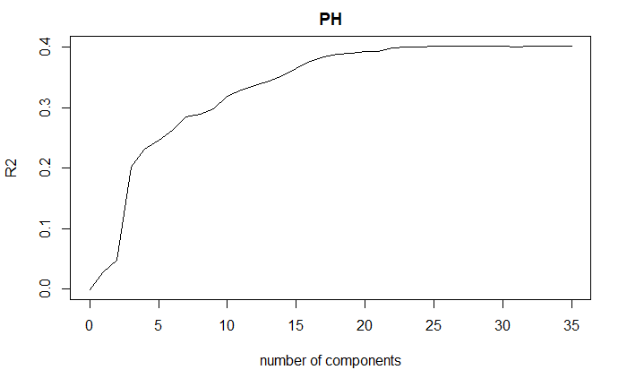

```r
validationplot(plsFit, val.type="R2")
```

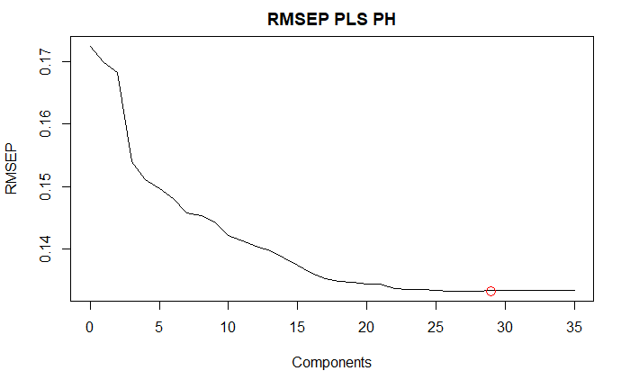

```r
pls.RMSEP = RMSEP(plsFit, estimate="CV")
plot(pls.RMSEP, main="RMSEP PLS PH", xlab="Components")
min_comp = which.min(pls.RMSEP$val)
points(min_comp, min(pls.RMSEP$val), pch=1, col="red", cex=1.5)
```

```r
min_comp
```

```
[1] 29
```

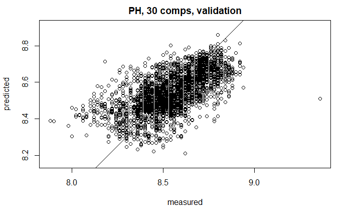

```r
plot(plsFit, ncomp=30, asp=1, line=TRUE)
```

```r
pls.pred2 = predict(plsFit, dfPredImp, ncomp=30)
summary(pls.pred2)
```

```
   Min. 1st Qu.  Median    Mean 3rd Qu.    Max.
  8.205   8.469   8.537   8.544   8.626   8.808
```

With the vast amounts of algorithms available, several should be explored to help make accurate predictions on the dataset. Linear regression is often the simple first step as these models are fast to train albeit with a high bias. The final models are typically easier to analyze and if they are accurate enough it may save moving on to more complex non-linear models. In this example we will start with a simple Generalized Linear Model (GLM) to perform a logistic regression, mix in more complex models then compare the results. A 10-fold cross validation is used for comparison and although not utilized below, a repeated cross validation can be set although it should be noted that repeating a cross valdation with exactly the same splitting will yield exactly the same result for every repetition.

Non-linear algorithms make fewer assumptions about the function being modeled so this will result in higher variance but often result in higher accuracy. Because of its flexibility these models tend to be slower to train and may require increased memory resources. We will explore a Neural Network and MARS model in further detail but will take a quick look at a k-Nearest Neigbor (KNN) and a Support Vector Machine (SVM) algorithm below.

Classification and Regression Trees (CART) and a Bagged CART are also compared below. CART split attributes based on values that minimize a loss function such as RMSE in the below example. Bagging CART is an ensemble method, which we will explore further later, that creates multiple models of the same type from different subsets of the same data. The predictions are then combined together for better results. This approach is particularly useful for high variance methods such as decision trees.

### GLM, SVM, KNN, CART, Bagged CART

```r
trainControl <- trainControl(method = "cv", number = 10)
#GLM
set.seed(1234)
fit.glm <- train(PH~., data=dfModImp, method="glm", metric="RMSE", trControl=trainControl,
           tuneLength = 5, preProc = c("center", "scale"))
fit.glm
```

```
Generalized Linear Model

2571 samples
  35 predictor

Pre-processing: centered (35), scaled (35)
Resampling: Cross-Validated (10 fold)
Summary of sample sizes: 2314, 2314, 2314, 2312, 2314, 2314, ...
Resampling results:

  RMSE       Rsquared   MAE
  0.1338559  0.4000127  0.1035896
```

```r
#SVM
set.seed(1234)
fit.svm <- train(PH~., data=dfModImp, method="svmLinear3", metric="RMSE", trControl=trainControl,                               tuneLength = 5, svr_eps = .1, preProc = c("center", "scale"))
fit.svm
```

```
L2 Regularized Support Vector Machine (dual) with Linear Kernel

2571 samples
  35 predictor

Pre-processing: centered (35), scaled (35)
Resampling: Cross-Validated (10 fold)
Summary of sample sizes: 2314, 2314, 2314, 2312, 2314, 2314, ...
Resampling results across tuning parameters:

  cost  Loss  RMSE       Rsquared   MAE
  0.25  L1    0.1437823  0.3642198  0.1162441
  0.25  L2    0.1348960  0.3900355  0.1041861
  0.50  L1    0.1423565  0.3631212  0.1146553
  0.50  L2    0.1354077  0.3855284  0.1044413
  1.00  L1    0.1453828  0.3534785  0.1173421
  1.00  L2    0.1348894  0.3923254  0.1041219
  2.00  L1    0.1468934  0.3461176  0.1186608
  2.00  L2    0.1376505  0.3697474  0.1062678
  4.00  L1    0.1467365  0.3461574  0.1184629
  4.00  L2    0.1414792  0.3512693  0.1099235

RMSE was used to select the optimal model using the smallest value.
The final values used for the model were cost = 1 and Loss = L2.
```

```r
#KNN
set.seed(1234)
fit.knn <- train(PH~., data=dfModImp, method="knn", metric="RMSE", trControl=trainControl,
          tuneLength = 5, preProc = c("center", "scale"))
fit.knn
```

```
k-Nearest Neighbors

2571 samples
  35 predictor

Pre-processing: centered (35), scaled (35)
Resampling: Cross-Validated (10 fold)
Summary of sample sizes: 2314, 2314, 2314, 2312, 2314, 2314, ...
Resampling results across tuning parameters:

  k   RMSE       Rsquared   MAE
   5  0.1196694  0.5256838  0.08817688
   7  0.1187173  0.5315663  0.08835740
   9  0.1194855  0.5259687  0.08970248
  11  0.1203907  0.5198816  0.09045212
  13  0.1208581  0.5170561  0.09148070

RMSE was used to select the optimal model using the smallest value.
The final value used for the model was k = 7.
```

```r
#CART
set.seed(1234)
fit.cart <- train(PH~., data=dfModImp, method="rpart", metric="RMSE", trControl=trainControl,
          tuneLength = 5, preProc = c("center", "scale"))
fit.cart
```

```
CART

2571 samples
  35 predictor

Pre-processing: centered (35), scaled (35)
Resampling: Cross-Validated (10 fold)
Summary of sample sizes: 2314, 2314, 2314, 2312, 2314, 2314, ...
Resampling results across tuning parameters:

  cp          RMSE       Rsquared   MAE
  0.02037425  0.1384641  0.3560877  0.1086759
  0.03075967  0.1405148  0.3368233  0.1108816
  0.04078032  0.1444536  0.3009936  0.1143715
  0.06398129  0.1521884  0.2248241  0.1188151
  0.21964083  0.1639390  0.1895098  0.1301241

RMSE was used to select the optimal model using the smallest value.
The final value used for the model was cp = 0.02037425.
```

```r
#Bagged CART
set.seed(1234)
fit.bagcart <- train(PH~., data=dfModImp, method="treebag", metric="RMSE", trControl=trainControl,
          tuneLength = 5, preProc = c("center", "scale"))
fit.bagcart
```

```
Bagged CART

2571 samples
  35 predictor

Pre-processing: centered (35), scaled (35)
Resampling: Cross-Validated (10 fold)
Summary of sample sizes: 2314, 2314, 2314, 2312, 2314, 2314, ...
Resampling results:

  RMSE      Rsquared   MAE
  0.120062  0.5194812  0.09299898
```

```r
#Compare results of the algorithms we ran
results <- resamples(list(GLM=fit.glm, SVM=fit.svm, KNN=fit.knn, CART=fit.cart, BaggedCart=fit.bagcart))
summary(results)
```

```
Call:
summary.resamples(object = results)

Models: GLM, SVM, KNN, CART, BaggedCart
Number of resamples: 10

MAE
                 Min.    1st Qu.     Median       Mean    3rd Qu.       Max. NA's
GLM        0.09585046 0.10021927 0.10244895 0.10358963 0.10818954 0.10980309    0
SVM        0.09799524 0.10020100 0.10335555 0.10412189 0.10829421 0.11111566    0
KNN        0.08306226 0.08563785 0.08736467 0.08835740 0.09148177 0.09610006    0
CART       0.10094110 0.10637012 0.10826234 0.10867594 0.11115543 0.11956784    0
BaggedCart 0.08587029 0.08917353 0.09231951 0.09299898 0.09510442 0.10366872    0

RMSE
                Min.   1st Qu.    Median      Mean   3rd Qu.      Max. NA's
GLM        0.1246130 0.1287928 0.1312447 0.1338559 0.1400975 0.1441090    0
SVM        0.1228335 0.1311924 0.1326627 0.1348894 0.1405673 0.1451442    0
KNN        0.1088853 0.1136461 0.1162121 0.1187173 0.1243730 0.1328615    0
CART       0.1266143 0.1334522 0.1378110 0.1384641 0.1411369 0.1559994    0
BaggedCart 0.1109680 0.1135195 0.1185657 0.1200620 0.1255219 0.1374242    0

Rsquared
                Min.   1st Qu.    Median      Mean   3rd Qu.      Max. NA's
GLM        0.3362341 0.3897613 0.4018395 0.4000127 0.4229693 0.4548215    0
SVM        0.3269044 0.3836236 0.4043972 0.3923254 0.4099486 0.4311627    0
KNN        0.4759764 0.4893181 0.5318886 0.5315663 0.5714068 0.6005573    0
CART       0.2301207 0.3553431 0.3650612 0.3560877 0.3730133 0.4058468    0
BaggedCart 0.3965062 0.5151204 0.5286858 0.5194812 0.5464265 0.5748157    0
```

KNN performed the best from the above models with a mean RMSE of 0.1187173 and a mean R-Squared of 0.5315663. We will explore further to see if we can find better results.

Ensemble Regression Ensemble methods generally refer to models combining predictions, either in classification or regression, of several base estimators to improve robustness over a single estimator. The goal of ensemble regression is to combine many models in order to increase the prediction accuracy in learning problems with a numerical target. The focus will be on regression not classification with Random Forest and Gradient Boosting (GBM).

Regression trees tend to be unstable, a seemingly insignificant change in the data can have a large impact on the model. The Random Forest can help solve this problem through bagging. Bagging originates from bootstrap aggregating which is a machine learning techique proposed by Breiman to stabalize potentially unstable estimators. Essentially, each variable is given several opportunities to be in the model across multiple bootstrap samples and the final forecast will be the average forecast across all samples.

Gradient Boosting (GBM) is another ensemble method explored that is similarly applied to regression and classification problems. Boosting originated from the notion that weak learners can become better. The first successful boosting algorithm was Adaptive Boosting or AdaBoost. Later, based on this framework, GBM attempted to solve a numerical optimization problem by minimizing the loss of the model by adding weak learners using a gradient descent. These class of algorithms were described as stage-wise additive because a new weak learner is added incrementally, simultaneaously an existing weak learner is left unchanged.

### Random Forest

```r
library(randomForest)
set.seed(1234)
rf <- function(df,y){
       fitControl <- trainControl(method = "cv",
       number = 10, #5folds)

rfgrid <- expand.grid(interaction.depth = 2,
            n.trees = 500,
            shrinkage = 0.1,
            n.minobsinnode = 10))

return(train(df, y,
             method = "randomForest",
             tuneGrid = rfgrid,
             trControl = fitControl))
}
rf.fit.bcsx <- randomForest(dfTrainBCSX, dfTrainY)
rf.fit.bx   <- randomForest(dfTrainBX, dfTrainY)
rf.fit.x    <- randomForest(dfTrainX,    dfTrainY)
```

```r
list(RMSE_RF.BCSX = RMSE(predict(rf.fit.bcsx, dfTestBCSX), dfTestY),
     RMSE_RF.BCS  = RMSE(predict(rf.fit.bx, dfTestBX), dfTestY),
     RMSE_RF.X    = RMSE(predict(rf.fit.x, dfTestX), dfTestY))
```

```
$RMSE_RF.BCSX
[1] 0.1136023

$RMSE_RF.BCS
[1] 0.1137173

$RMSE_RF.X
[1] 0.112871
```

```r
rf.fit.bcsx
```

```
Call:
 randomForest(x = dfTrainBCSX, y = dfTrainY)
               Type of random forest: regression
                     Number of trees: 500
No. of variables tried at each split: 5

          Mean of squared residuals: 0.01345612
                    % Var explained: 55.01
```

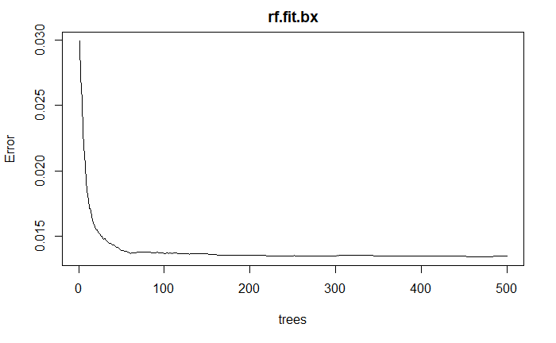

```r
plot(rf.fit.bx)
```

### GBM

```r
library(caret)
set.seed(1234)
gbm <- function(df,y){
       fitControl <- trainControl(method = "cv",
       number = 10)

gbmgrid <- expand.grid(interaction.depth = 2,
            n.trees = 500,
            shrinkage = 0.1,
            n.minobsinnode = 10)

return(train(df, y,
             method = "gbm",
             tuneGrid = gbmgrid,
             trControl = fitControl,
             verbose = FALSE))
}
gbm.fit.bcsx <- gbm(dfTrainBCSX, dfTrainY)
gbm.fit.bx   <- gbm(dfTrainBX, dfTrainY)
gbm.fit.x    <- gbm(dfTrainX,    dfTrainY)
```

```r
list(RMSE_GBM.BCSX = RMSE(predict(gbm.fit.bcsx, dfTestBCSX), dfTestY),
     RMSE_GBM.BCS  = RMSE(predict(gbm.fit.bx, dfTestBX), dfTestY),
     RMSE_GBM.X    = RMSE(predict(gbm.fit.x, dfTestX), dfTestY))
```

```
$RMSE_GBM.BCSX
[1] 0.1246051

$RMSE_GBM.BCS
[1] 0.124799

$RMSE_GBM.X
[1] 0.1245754
```

|  | var | rel.inf |
| --- | --- | --- |
| Mnf.Flow | Mnf.Flow | 24.337765 |
| C | C | 14.248452 |
| Oxygen.Filler | Oxygen.Filler | 6.935360 |
| Density | Density | 6.808031 |
| Usage.cont | Usage.cont | 5.384097 |
| Filler.Level | Filler.Level | 5.155232 |
| PSC | PSC | 5.054647 |
| Filler.Speed | Filler.Speed | 4.271760 |
| PC.Volume | PC.Volume | 4.257600 |
| D | D | 3.528033 |

[output cut: 7 more lines]

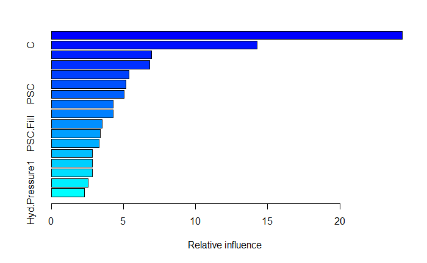

```r
summary(gbm.fit.bx, digit=3)
```

### Best Performing Regression Trees and Rule-based Models

We see an improvement with Random Forest, 0.112871 RMSE but GBM does not appear to perform better than the group of models with a RMSE of 0.1246051.

```r
list(RMSE_GBM.BCS = RMSE(predict(gbm.fit.bcsx, dfTestBCSX), dfTestY),
     RMSE_RF.X    = RMSE(predict(rf.fit.x, dfTestX), dfTestY))
```

```
$RMSE_GBM.BCS
[1] 0.1246051

$RMSE_RF.X
[1] 0.112871
```

## Nonlinear Models

Using the several data sets created from our previous transformations we attempted to fit several non-linear models. Specifically, a Neural Network and MARS model. While data transformations are not always necessary for the MARS method, we will nonetheless benefit from removing data features that would be adding unncessary noise to our final models. The Neural Network can be greatly impacted by highly correlated variables.

### Neural Network

Neural Networks can be thought of as models that work in similar ways to our brain. Inputs are provided and transformed at nodes by assigned weights that then feed-forward to any additional layers containing additional nodes [^1]. A drawback to this method is that without limitations on our linear combinations from one layer to another, the coefficients will have little context [^3].

[^1] Bishop, Christopher M. Neural Networks for Pattern Recognition. Oxford: New York: Clarendon Press; Oxford University Press, 1995.

[^3] Kuhn, Max, and Kjell Johnson. Applied Predictive Modeling. New York: Springer, 2013.

```r
set.seed(1234)
nnet <- function(df, y){

              fitControl <- trainControl(method = "cv",
                                         number = 3,
                                         returnResamp = "all")

              nnetGrid <- expand.grid(.decay = c(0, 0.01, .1, .5),
                                      .size = c(5:15),
                                      .bag = FALSE)

                 return(train(df, y,
                              method = "avNNet",
                              tuneGrid = nnetGrid,
                              trControl = fitControl,
                              trace = FALSE,
                              linout = TRUE))
}
nnet.fit.bcsx <- nnet(dfTrainBCSX, dfTrainY)
nnet.fit.bx   <- nnet(dfTrainBX,   dfTrainY)
nnet.fit.x    <- nnet(dfTrainX,    dfTrainY)
```

Now that we have trained our models on the available data sets, we will measure the root mean squared error of all three and select the lowest.

```r
list(RMSE_NNET.BCSX = RMSE(predict(nnet.fit.bcsx, dfTestBCSX), dfTestY),
     RMSE_NNET.BCS  = RMSE(predict(nnet.fit.bx,   dfTestBX), dfTestY),
     RMSE_NNET.X    = RMSE(predict(nnet.fit.x,    dfTestX), dfTestY))
```

```
$RMSE_NNET.BCSX
[1] 0.1252859

$RMSE_NNET.BCS
[1] 0.1584323

$RMSE_NNET.X
[1] 0.1468655
```

Based on our RMSE results the final model chosen for the neural network is `nnet.fit.bcsx`

```r
nnet.fit.bcsx$finalModel
```

```
Model Averaged Neural Network with 5 Repeats

a 17-9-1 network with 172 weights
options were - linear output units
```

```r
varImp(nnet.fit.bcsx)
```

```
loess r-squared variable importance

              Overall
Mnf.Flow      100.000
Usage.cont     43.040
Filler.Speed   35.164
Hyd.Pressure4  33.744
Filler.Level   30.054
Density        29.232
Hyd.Pressure2  26.193
Hyd.Pressure1  25.302
C              24.715
Oxygen.Filler  23.245
B              18.710
PSC             8.391
PSC.CO2         4.058
PC.Volume       3.394
PSC.Fill        2.413
A               2.344
D               0.000
```

The grid parameters we set earlier are plotted below to visualize how tuning impacts the model performance.

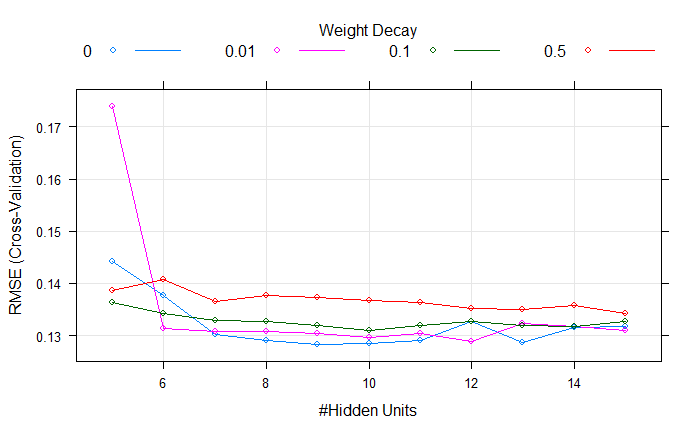

```r
plot(nnet.fit.bcsx)
```

### MARS Model

The Multivariate Adaptive Regression Splines or “MARS” model is a nonparametric method, i.e. we are not required to make any assumptions about any underlying distributions such as the neural network. It can achieve this by pivoting on naturally occuring breaks in the data set and essentially building a model out of many linear models developed for specific segemets of the data set [^2] [^3].

[^2] J.H. Friedman, “Multivariate adaptive regression splines”, The Annals of Statistics, 19 (1991), pp. 1-141

[^3] Kuhn, Max, and Kjell Johnson. Applied Predictive Modeling. New York: Springer, 2013.

```r
library(caret)
set.seed(1234)
mars <- function(df, y){

          fitControl <- trainControl(method = "cv",
                                     number = 3,
                                     returnResamp = "all")
          MARSGrid <- expand.grid(degree= 3:5,
                                  nprune = seq(20,60,20))

          return(train(df, y,
                 method = "earth",
                 tuneGrid = MARSGrid,
                 trControl = fitControl))
         }
mars.fit.bcsx <- mars(dfTrainBCSX, dfTrainY)
mars.fit.bx   <- mars(dfTrainBX,   dfTrainY)
mars.fit.x    <- mars(dfTrainX,    dfTrainY)
```

Now that we have trained our models on the available data sets, we will measure the root mean squared error of all three and select the lowest.

```r
list(RMSE_MARS.BCSX = RMSE(predict(mars.fit.bcsx, dfTestBCSX), dfTestY),
     RMSE_MARS.BCS  = RMSE(predict(mars.fit.bx,   dfTestBX), dfTestY),
     RMSE_MARS.X    = RMSE(predict(mars.fit.x,    dfTestX), dfTestY))
```

```
$RMSE_MARS.BCSX
[1] 0.1312386

$RMSE_MARS.BCS
[1] 0.1994629

$RMSE_MARS.X
[1] 0.2370551
```

```r
mars.fit.bcsx$finalModel
```

```
Selected 20 of 33 terms, and 12 of 17 predictors
Termination condition: Reached nk 35
Importance: Mnf.Flow, A, C, Filler.Level, B, Oxygen.Filler, Usage.cont, Hyd.Pressure2, Filler.Speed, Density, ...
Number of terms at each degree of interaction: 1 5 10 4
GCV 0.01651975    RSS 30.26781    GRSq 0.4482671    RSq 0.475132
```

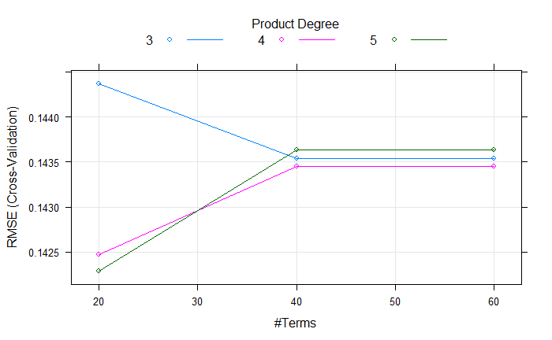

```r
plot(mars.fit.bcsx)
```

In our final MARS model, the variable of greatest importance is `Mnf.Flow`.

```r
varImp(mars.fit.bcsx)
```

```
earth variable importance

              Overall
Mnf.Flow       100.00
A               75.01
C               75.01
Filler.Level    59.35
B               54.45
Oxygen.Filler   50.66
Usage.cont      47.73
Hyd.Pressure2   42.59
Filler.Speed    32.20
Density         32.20
PSC             28.31
PC.Volume       23.68
Hyd.Pressure1    0.00
PSC.Fill         0.00
PSC.CO2          0.00
Hyd.Pressure4    0.00
D                0.00
```

### Best Performing Nonlinear Model

```r
list(RMSE_MARS = RMSE(predict(mars.fit.bcsx, dfTestBCSX), dfTestY),
     RMSE_NNET = RMSE(predict(nnet.fit.bcsx, dfTestBCSX), dfTestY))
```

```
$RMSE_MARS
[1] 0.1312386

$RMSE_NNET
[1] 0.1252859
```

# Model Selection

Conclusion

Often the goal of model selection is to choose the best fit for future prediction after exhaustively running iterations of various methods. Selecting the best fit is typically done by measuring the accuracy of predictions with a squared error loss. Assessing the fit of regression models can be challenging but different methodologies can be employed to accomplish this goal.

We decided to focus on the Root Mean Squared Error (RMSE) or the square root of the variance of the residuals. The RMSE determines the absolute fit of the model to the data, which measures the closeness of the observed data points to the model’s predicted values. Lower RMSE values are better indicators of fit and is widely regarded as the most important measure of accuracy when performing predictions.

Several of the models we ran had RMSE values that were pretty close, however we concluded that there was incremental improvement with Random Forest because it met this criterion, lowest RMSE.

## Final Model

```r
rf.fit.x
```

```
Call:
 randomForest(x = dfTrainX, y = dfTrainY)
               Type of random forest: regression
                     Number of trees: 500
No. of variables tried at each split: 5

          Mean of squared residuals: 0.01345482
                    % Var explained: 55.02
```

# Predictions

```r
library(xlsx)
dfPredImp$PH <- predict(rf.fit.x, dfPredBX)
dfPredImp <- dfPredImp %>%  select(PH, everything())
write.xlsx(dfPredImp, "./data/StudentEvaluation- TO PREDICT wPredictions.xlsx", row.names = FALSE)
```

# Appendix A

## Session Info

R version 3.4.1 (2017-06-30) Platform: x86_64-w64-mingw32/x64 (64-bit) Running under: Windows >= 8 x64 (build 9200)

Matrix products: default

locale: [1] LC_COLLATE=English_United States.1252 LC_CTYPE=English_United States.1252  
[3] LC_MONETARY=English_United States.1252 LC_NUMERIC=C  
[5] LC_TIME=English_United States.1252

attached base packages: [1] stats graphics grDevices utils datasets methods base

other attached packages: [1] earth_4.5.1 plotmo_3.3.4 TeachingDemos_2.10  
[4] plotrix_3.7 Metrics_0.1.3 forcats_0.2.0  
[7] stringr_1.2.0 dplyr_0.7.4 purrr_0.2.4  
[10] readr_1.1.1 tidyr_0.7.2 tibble_1.3.4  
[13] tidyverse_1.2.1 e1071_1.6-8 rpart_4.1-11  
[16] elasticnet_1.1 pls_2.6-0 lars_1.2  
[19] AppliedPredictiveModeling_1.1-6 MASS_7.3-47 mlbench_2.1-1  
[22] xlsx_0.5.7 xlsxjars_0.6.1 rJava_0.9-9  
[25] corrplot_0.84 knitr_1.17 psych_1.7.8  
[28] caret_6.0-78 ggplot2_2.2.1 lattice_0.20-35  
[31] corrgram_1.12 missForest_1.4 itertools_0.1-3  
[34] iterators_1.0.8 foreach_1.4.3 randomForest_4.6-12

loaded via a namespace (and not attached): [1] readxl_1.0.0 backports_1.1.1 plyr_1.8.4 lazyeval_0.2.1 splines_3.4.1 digest_0.6.12  
[7] htmltools_0.3.6 viridis_0.4.0 gdata_2.18.0 magrittr_1.5 cluster_2.0.6 gclus_1.3.1  
[13] sfsmisc_1.1-1 recipes_0.1.1 modelr_0.1.1 gower_0.1.2 dimRed_0.1.0 colorspace_1.3-2  
[19] rvest_0.3.2 haven_1.1.0 crayon_1.3.4 jsonlite_1.5 bindr_0.1 survival_2.41-3  
[25] glue_1.2.0 DRR_0.0.2 registry_0.5 gtable_0.2.0 ipred_0.9-6 kernlab_0.9-25  
[31] ddalpha_1.3.1 prabclus_2.2-6 DEoptimR_1.0-8 scales_0.5.0 mvtnorm_1.0-6 Rcpp_0.12.14  
[37] CORElearn_1.51.2 viridisLite_0.2.0 foreign_0.8-69 mclust_5.4 stats4_3.4.1 lava_1.5.1  
[43] prodlim_1.6.1 httr_1.3.1 gplots_3.0.1 fpc_2.1-10 modeltools_0.2-21 pkgconfig_2.0.1  
[49] flexmix_2.3-14 nnet_7.3-12 tidyselect_0.2.3 rlang_0.1.4 reshape2_1.4.2 munsell_0.4.3  
[55] cellranger_1.1.0 tools_3.4.1 cli_1.0.0 broom_0.4.3 evaluate_0.10.1 yaml_2.1.15  
[61] ModelMetrics_1.1.0 robustbase_0.92-8 caTools_1.17.1 dendextend_1.6.0 bindrcpp_0.2 nlme_3.1-131  
[67] whisker_0.3-2 RcppRoll_0.2.2 xml2_1.1.1 compiler_3.4.1 rstudioapi_0.7 stringi_1.1.6  
[73] highr_0.6 trimcluster_0.1-2 Matrix_1.2-12 gbm_2.1.3 LiblineaR_2.10-8 bitops_1.0-6  
[79] seriation_1.2-2 R6_2.2.2 TSP_1.1-5 KernSmooth_2.23-15 gridExtra_2.3 codetools_0.2-15  
[85] gtools_3.5.0 assertthat_0.2.0 CVST_0.2-1 rprojroot_1.2 withr_2.1.0 mnormt_1.5-5  
[91] diptest_0.75-7 parallel_3.4.1 hms_0.4.0 grid_3.4.1 timeDate_3042.101 class_7.3-14  
[97] rmarkdown_1.8 lubridate_1.7.1 base64enc_0.1-3

## All Code Used

```r
knitr::opts_chunk$set(echo = TRUE, message=FALSE, warning=FALSE, cache=TRUE)
library(missForest)
library(corrgram)
library(caret)
library(psych)
library(knitr)

dfBevMod <- read.csv("https://github.com/ChristopheHunt/CUNY-DATA624/raw/master/data/StudentData.csv", header = TRUE)
dfBevPred <- read.csv("https://raw.githubusercontent.com/ChristopheHunt/CUNY-DATA624/master/data/StudentEvaluation-%20TO%20PREDICT.csv", header =TRUE)
dim(dfBevMod)
colSums(is.na(dfBevMod))
#Visualizing the single categorical variable
barchart(dfBevMod[,1], col="Gold")
library(psych)
library(knitr)
table.desc <- describe(dfBevMod[,-1])
table.prep <- as.matrix(table.desc)
table.round <- round((table.prep), 2)
kable(table.round)
dfBevModH <- dfBevMod[2:ncol(dfBevMod)] #removing factor var
par(mfrow = c(3,5), cex = .5)
for(i in colnames(dfBevModH)){
hist(dfBevModH[,i], xlab = names(dfBevMod[i]),
  main = names(dfBevModH[i]), col="grey", ylab="")
}
BrandA <- dfBevMod[dfBevMod$Brand.Code == "A",]
BAM <- colMeans(BrandA[,2:ncol(BrandA)], na.rm = TRUE)
BrandB <- dfBevMod[dfBevMod$Brand.Code == "B",]
BBM <- colMeans(BrandB[,2:ncol(BrandB)], na.rm = TRUE)
BrandC <- dfBevMod[dfBevMod$Brand.Code == "C",]
BCM <- colMeans(BrandC[,2:ncol(BrandC)], na.rm = TRUE)
BrandD <- dfBevMod[dfBevMod$Brand.Code == "D",]
BDM <- colMeans(BrandD[,2:ncol(BrandD)], na.rm = TRUE)
BrandE <- dfBevMod[dfBevMod$Brand.Code == "",]
BEM <- colMeans(BrandE[,2:ncol(BrandE)], na.rm = TRUE)

combBrand <- cbind(BAM, BBM, BCM, BDM, BEM)
round(combBrand, 4)
par(mfrow = c(3,5), cex = .5)
for (i in colnames(dfBevModH)) {
 smoothScatter(dfBevModH[,i], main = names(dfBevModH[i]), ylab = "",
   xlab = "", colramp = colorRampPalette(c("white", "red")))
 }
par(mfrow = c(3,5), cex = .5)
for(i in colnames(dfBevModH)){
boxplot(dfBevModH[,i], xlab = names(dfBevModH[i]),
  main = names(dfBevModH[i]), col="grey", ylab="")
}
PCA <- function(X) {
  Xpca <- prcomp(na.omit(X), center = T, scale. = T)
  M <- as.matrix(na.omit(X)); R <- as.matrix(Xpca$rotation); score <- M %*% R
  print(list("Importance of Components" = summary(Xpca)$importance[ ,1:5],
             "Rotation (Variable Loadings)" = Xpca$rotation[ ,1:5],
             "Correlation between X and PC" = cor(na.omit(X), score)[ ,1:5]))
  par(mfrow=c(2,3))
  barplot(Xpca$sdev^2, ylab = "Component Variance")
  barplot(cor(cbind(X)), ylab = "Correlations")
  barplot(Xpca$rotation, ylab = "Loadings")
  biplot(Xpca); barplot(M); barplot(score)
}
PCA(dfBevModH)
#df_imputed$Brand.Code = NULL
dfBevMod$Brand.Code[dfBevMod$Brand.Code == ""] <- NA
dfBevMod$Brand.Code <- droplevels(dfBevMod$Brand.Code)

dfBevPred$Brand.Code[dfBevPred$Brand.Code == ""] <- NA
dfBevPred$Brand.Code <- droplevels(dfBevPred$Brand.Code)

#Recode categorical factor
dfBevMod$A <- ifelse(dfBevMod$Brand.Code == "A", 1, 0)
dfBevMod$B <- ifelse(dfBevMod$Brand.Code == "B", 1, 0)
dfBevMod$C <- ifelse(dfBevMod$Brand.Code == "C", 1, 0)
dfBevMod$D <- ifelse(dfBevMod$Brand.Code == "D", 1, 0)
dfBevMod$Brand.Code <- NULL

dfBevPred$A <- ifelse(dfBevPred$Brand.Code == "A", 1, 0)
dfBevPred$B <- ifelse(dfBevPred$Brand.Code == "B", 1, 0)
dfBevPred$C <- ifelse(dfBevPred$Brand.Code == "C", 1, 0)
dfBevPred$D <- ifelse(dfBevPred$Brand.Code == "D", 1, 0)
dfBevPred$Brand.Code <- NULL
library(tidyverse)
#dfImpMod = missForest(dfBevMod)
#dfImpMod$OOBerror #error rate looks good?
#dfModImp <- dfImpMod$ximp

#dfImpPred <- missForest(dfBevPred)
#dfPredImp <- dfImpPred$ximp
#dfPredImp$PH <- NA #redadding PH

#write.csv(dfModImp, "TrainImputeData.csv")
#write.csv(dfPredImp, "PredictImputeData.csv")

#Stored current imputation results on github to quicken knitr iterations
dfModImp <- read.csv("https://raw.githubusercontent.com/ChristopheHunt/CUNY-DATA624/master/data/TrainImputeData.csv") %>% dplyr::select(-X)
dfPredImp <- read.csv("https://raw.githubusercontent.com/ChristopheHunt/CUNY-DATA624/master/data/PredictImputeData.csv") %>% dplyr::select(-X)

dfModImpX <- dfModImp[,!(names(dfModImp) == "PH")]
dfModImpY <- dfModImp[, names(dfModImp) == "PH"]

dfPredImpX <- dfPredImp[,!(names(dfPredImp) == "PH")]
dfPredImpY <- dfPredImp[, names(dfPredImp) == "PH"]

#Spatial Sign outlier processing
dfModImpSsX <- spatialSign(dfModImpX)
dfPredImpSsX <- spatialSign(dfPredImpX)

#BoxCox Only
transModB <- preProcess(dfModImpSsX, method = "BoxCox") #transformed all 22 variables
dfModBX <- predict(transModB, dfModImpSsX)

transPredB <- preProcess(dfPredImpSsX, method = "BoxCox") #transformed 23 variables (should we use the Modeling model from above, instead of predicting model?)
dfPredBX <- predict(transPredB, dfPredImpSsX)

#BoxCox, Centering, and Scaling
transModBCS <- preProcess(dfModImpSsX, method = c("BoxCox", "center", "scale")) #22 BC, 35 centered, 35 scaled
dfModBCSX <- predict(transModBCS, dfModImpSsX)

transPredBCS <- preProcess(dfPredImpSsX, method = c("BoxCox", "center", "scale")) #23 BC, 35 centered, 35 scaled
dfPredBCSX <- predict(transPredBCS, dfPredImpSsX)

#BoxCox, Centering, Scaling, and PCA
transModBCSP <- preProcess(dfModImpSsX, method = c("BoxCox", "center", "scale", "pca")) #22 BC, 35 centered, 35 scaled
dfModBCSPX <- predict(transModBCSP, dfModImpSsX)

transPredBCSP <- preProcess(dfPredImpSsX, method = c("BoxCox", "center", "scale", "pca")) #23 BC, 35 centered, 35 scaled
dfPredBCSPX <- predict(transPredBCSP, dfPredImpSsX)
#corrgram(dfModBCSX, order=TRUE,
#         upper.panel=panel.cor, main="Correlation Matrix")
library(corrplot)
#install.packages("corrplot")
correlations <- cor(dfModBCSX)
corrplot(correlations, order = "hclust", tl.cex = 0.55)
hc = findCorrelation(correlations, cutoff=0.75)
length(hc) #18 vars

#Reducing
dfModBCSRX = dfModBCSX[,-c(hc)] #Box-Cox, Center, Scale
dfPredBCSRX = dfPredBCSX[,-c(hc)]

dfModBRX = dfModBX[,-c(hc)] #Box-Cox
dfPredBRX = dfPredBX[,-c(hc)]

dfModSRX = dfModImpSsX[,-c(hc)] #Only Spatial Sign
dfPredSRX = dfPredImpSsX[,-c(hc)]
set.seed(2017)
n75 <- floor(0.75 * nrow(dfBevMod)) #75$ of sample size
n <- sample(seq_len(nrow(dfBevMod)), size = n75)
```

```r
#Box-Cox, Center, Scale
dfTrainBCSX <- dfModBCSRX[n,]
dfTestBCSX <- dfModBCSRX[-n,]

#Box-Cox
dfTrainBX <- dfModBRX[n,]
dfTestBX <- dfModBRX[-n,]

#Only Spatial Sign
dfTrainX <- dfModSRX[n,]
dfTestX <- dfModSRX[-n,]

#Response variable
dfTrainY <- dfModImpY[n]
dfTestY <- dfModImpY[-n]

knitr::opts_chunk$set(echo = TRUE)
library(caret)
library(mlbench)
library(MASS)
library(AppliedPredictiveModeling)
library(lars)
library(pls)
library(elasticnet)
library(rpart)
library(e1071)
set.seed(1234)
plsFit = plsr(PH ~ ., data=dfModImp, validation="CV")
pls.pred = predict(plsFit, dfPredImp[1:5, ], ncomp=1:2)

pls.pred

validationplot(plsFit, val.type="RMSEP")
validationplot(plsFit, val.type="R2")

pls.RMSEP = RMSEP(plsFit, estimate="CV")
plot(pls.RMSEP, main="RMSEP PLS PH", xlab="Components")
min_comp = which.min(pls.RMSEP$val)
points(min_comp, min(pls.RMSEP$val), pch=1, col="red", cex=1.5)

min_comp

plot(plsFit, ncomp=30, asp=1, line=TRUE)

pls.pred2 = predict(plsFit, dfPredImp, ncomp=30)
summary(pls.pred2)
trainControl <- trainControl(method = "cv", number = 10)

#GLM
set.seed(1234)
fit.glm <- train(PH~., data=dfModImp, method="glm", metric="RMSE", trControl=trainControl,
           tuneLength = 5, preProc = c("center", "scale"))
fit.glm

#SVM
set.seed(1234)
fit.svm <- train(PH~., data=dfModImp, method="svmLinear3", metric="RMSE", trControl=trainControl,                               tuneLength = 5, svr_eps = .1, preProc = c("center", "scale"))
fit.svm

#KNN
set.seed(1234)
fit.knn <- train(PH~., data=dfModImp, method="knn", metric="RMSE", trControl=trainControl,
          tuneLength = 5, preProc = c("center", "scale"))
fit.knn

#CART
set.seed(1234)
fit.cart <- train(PH~., data=dfModImp, method="rpart", metric="RMSE", trControl=trainControl,
          tuneLength = 5, preProc = c("center", "scale"))
fit.cart

#Bagged CART
set.seed(1234)
fit.bagcart <- train(PH~., data=dfModImp, method="treebag", metric="RMSE", trControl=trainControl,
          tuneLength = 5, preProc = c("center", "scale"))
fit.bagcart

#Compare results of the algorithms we ran
results <- resamples(list(GLM=fit.glm, SVM=fit.svm, KNN=fit.knn, CART=fit.cart, BaggedCart=fit.bagcart))

summary(results)

library(randomForest)

set.seed(1234)

rf <- function(df,y){
       fitControl <- trainControl(method = "cv",
       number = 10, #5folds)

rfgrid <- expand.grid(interaction.depth = 2,
            n.trees = 500,
            shrinkage = 0.1,
            n.minobsinnode = 10))

return(train(df, y,
             method = "randomForest",
             tuneGrid = rfgrid,
             trControl = fitControl))
}

rf.fit.bcsx <- randomForest(dfTrainBCSX, dfTrainY)
rf.fit.bx   <- randomForest(dfTrainBX, dfTrainY)
rf.fit.x    <- randomForest(dfTrainX,    dfTrainY)
list(RMSE_RF.BCSX = RMSE(predict(rf.fit.bcsx, dfTestBCSX), dfTestY),
     RMSE_RF.BCS  = RMSE(predict(rf.fit.bx, dfTestBX), dfTestY),
     RMSE_RF.X    = RMSE(predict(rf.fit.x, dfTestX), dfTestY))
rf.fit.bcsx
plot(rf.fit.bx)

library(caret)

set.seed(1234)

gbm <- function(df,y){
       fitControl <- trainControl(method = "cv",
       number = 10)

gbmgrid <- expand.grid(interaction.depth = 2,
            n.trees = 500,
            shrinkage = 0.1,
            n.minobsinnode = 10)

return(train(df, y,
             method = "gbm",
             tuneGrid = gbmgrid,
             trControl = fitControl,
             verbose = FALSE))
}

gbm.fit.bcsx <- gbm(dfTrainBCSX, dfTrainY)
gbm.fit.bx   <- gbm(dfTrainBX, dfTrainY)
gbm.fit.x    <- gbm(dfTrainX,    dfTrainY)
list(RMSE_GBM.BCSX = RMSE(predict(gbm.fit.bcsx, dfTestBCSX), dfTestY),
     RMSE_GBM.BCS  = RMSE(predict(gbm.fit.bx, dfTestBX), dfTestY),
     RMSE_GBM.X    = RMSE(predict(gbm.fit.x, dfTestX), dfTestY))
summary(gbm.fit.bx, digit=3)
list(RMSE_GBM = RMSE(predict(gbm.fit.bcsx, dfTestBCSX), dfTestY),
     RMSE_RF  = RMSE(predict(rf.fit.x, dfTestX), dfTestY))
library(caret)
library(tidyverse)
library(Metrics)
set.seed(1234)

nnet <- function(df, y){

              fitControl <- trainControl(method = "cv",
                                         number = 3,
                                         returnResamp = "all")

              nnetGrid <- expand.grid(.decay = c(0, 0.01, .1, .5),
                                      .size = c(5:15),
                                      .bag = FALSE)

                 return(train(df, y,
                              method = "avNNet",
                              tuneGrid = nnetGrid,
                              trControl = fitControl,
                              trace = FALSE,
                              linout = TRUE))
}

nnet.fit.bcsx <- nnet(dfTrainBCSX, dfTrainY)
nnet.fit.bx   <- nnet(dfTrainBX,   dfTrainY)
nnet.fit.x    <- nnet(dfTrainX,    dfTrainY)
list(RMSE_NNET.BCSX = RMSE(predict(nnet.fit.bcsx, dfTestBCSX), dfTestY),
     RMSE_NNET.BCS  = RMSE(predict(nnet.fit.bx,   dfTestBX), dfTestY),
     RMSE_NNET.X    = RMSE(predict(nnet.fit.x,    dfTestX), dfTestY))
nnet.fit.bcsx$finalModel
varImp(nnet.fit.bcsx)
plot(nnet.fit.bcsx)
library(caret)

set.seed(1234)

mars <- function(df, y){

          fitControl <- trainControl(method = "cv",
                                     number = 3,
                                     returnResamp = "all")

          MARSGrid <- expand.grid(degree= 3:5,
                                  nprune = seq(20,60,20))

          return(train(df, y,
                 method = "earth",
                 tuneGrid = MARSGrid,
                 trControl = fitControl))
         }

mars.fit.bcsx <- mars(dfTrainBCSX, dfTrainY)
mars.fit.bx   <- mars(dfTrainBX,   dfTrainY)
mars.fit.x    <- mars(dfTrainX,    dfTrainY)
list(RMSE_MARS.BCSX = RMSE(predict(mars.fit.bcsx, dfTestBCSX), dfTestY),
     RMSE_MARS.BCS  = RMSE(predict(mars.fit.bx,   dfTestBX), dfTestY),
     RMSE_MARS.X    = RMSE(predict(mars.fit.x,    dfTestX), dfTestY))
mars.fit.bcsx$finalModel
plot(mars.fit.bcsx)
varImp(mars.fit.bcsx)
list(RMSE_MARS = RMSE(predict(mars.fit.bcsx, dfTestBCSX), dfTestY),
     RMSE_NNET = RMSE(predict(nnet.fit.bcsx, dfTestBCSX), dfTestY))
rf.fit.x
library(tidyverse)
library(xlsx)
dfPredImp$PH <- predict(rf.fit.x, dfPredBX)
dfPredImp <- dfPredImp %>%  dplyr::select(PH, everything())
write.xlsx(dfPredImp, "./data/StudentEvaluation- TO PREDICT wPredictions.xlsx", row.names = FALSE)
sessionInfo()
```